# Aides Drug

Taylor Stohl

Summer 2021

# Introduction

A new preventative aides drug (triUmpsal) is under test in clinical trials. Consider only the females, does this drug seem effective? Hint - use dplyr to obtain that subpopulation with the filter command.

#Introduction:

# Results

## Descriptive Results

### Graphical Descriptive Results

```r
dd2 <- females %>% group_by(infected,treatment) %>% summarize(count=n()) %>% mutate(prcnt=count/sum(count))
```

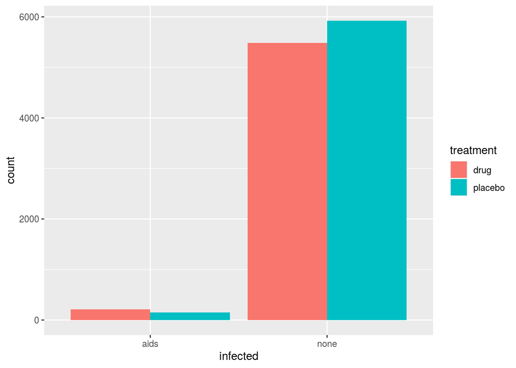

```r
# the group_by followed by summarize(count=n())

basicC <- ggplot(dd2,aes(x=infected,y=count,fill=treatment))
basicC + geom_bar(stat="identity",position="dodge")
```

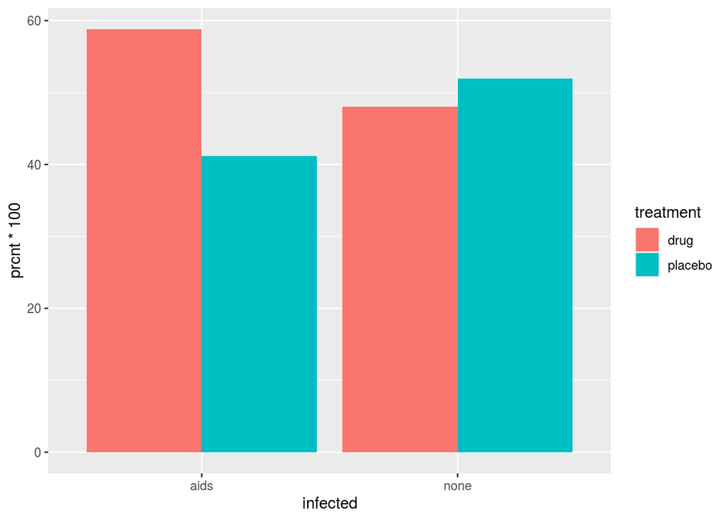

```r
#Now for percentage plot

basicCC <- ggplot(dd2,aes(x=infected,y=prcnt*100,fill=treatment))
basicCC + geom_bar(stat="identity", position = "dodge")
```

There are two plots. In first plot,the x-axis represents infected, whether the participants were infected with aids or they were not. The y-axis represents the count, or number of people that got aids or didn’t get aids.

In the second plot, the one above, The The left two bars of the graph are all the people that got aids. The x-axis represents whether a person got aids or not. The y-axis, however, instead of representing the number of people who got aids, now represents the percentage of people that got aids after taking the the placebo or taking the drug triUmpsal.

The codes that create this plot start with the code block beginning with dd2. dd2 can be seen in the environment pane and if inspected contains 4 variables.These variables include infected, treatment, count, and prcent(stands for percent). The second group of codes is called the basicC. BasicC can also be seen in the environment pane and appears to contain a list of 9 variables. This information creates the first plot. The basicCC is the last bunch of codes and is also in the files pane. It also contains 9 variables and helps to create the percentage plot, the second plot.